# Non Indigenous Species in benthic and Planktonic realm of the Ob Bay

# Гидрологические условия в акватории Обской губы

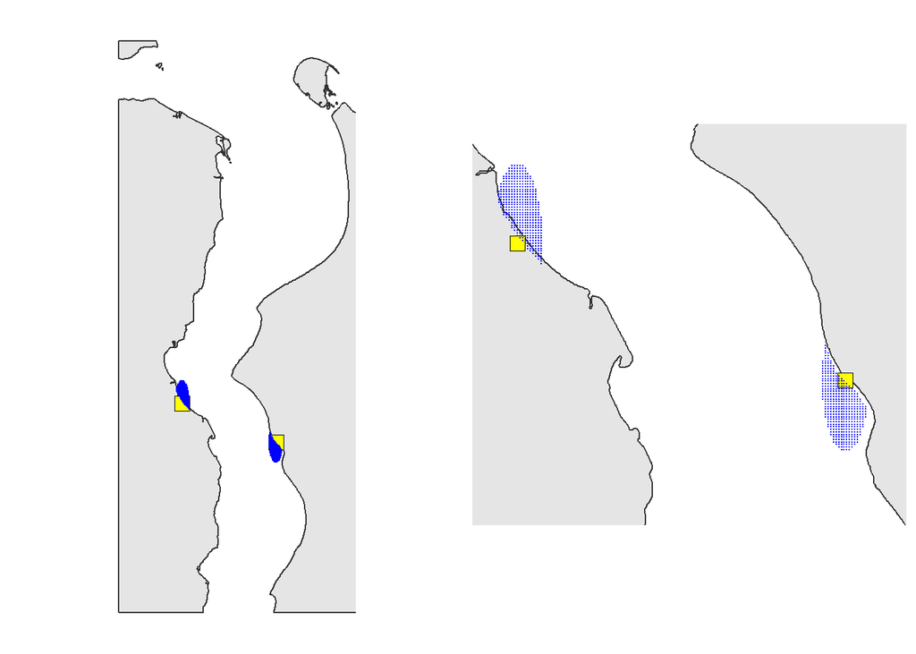

### Гидрологические условия в районе портов

Для характеристики гидрологических условий акватории были использованы два источника данных. Во-первых, были использованы данные предсказаний модели INMOM. Гидродинамическая модель была построена на основе хорошо протестированной российской универсальной трехмерной σ-модели морской и океанической циркуляции INMOM (Institute of Numerical Mathematics Ocean Model), которая была создана в Институте вычислительной математики Российской академии наук (ИВМ РАН)[ Дианский, Н. А. (2013). Моделирование циркуляции океана и изучение его реакции на кратковременные и долговременные атмосферные воздействия. Москва: Физматлит, 272.]. Следует отметить, что сложная вертикальная структура течений Обской губы делает практически невозможным использование упрощенных двумерных моделей для расчета термогидродинамических характеристик залива без учета стратификации плотности, даже несмотря на его относительную мелководность. Для корректного воспроизведения плотностной стратификации Обской губы использование трехмерных гидротермодинамических моделей полностью оправдано.

Модель INMOM хорошо зарекомендовала себя при решении практических задач расчета гидрологических характеристик в различных морях России, а также в международных проектах. Глобальные версии INMOM служат океаническими блоками в различных версиях модели земной системы Института численной математической модели климата (INMCM)[ Volodin, E. M., Mortikov, E. V., Kostrykin, S. V., Galin, V. Ya., Lykossov, V. N., Gritsun, A. S., Diansky, N. A., Gusev, A. V., Iakovlev, N. G. (2017). Моделирование современного климата с помощью климатической модели INMCM5. Climate. Dynamics. DOI: 10.1007/s00382-017-3539-7], созданной в ИВМ РАН и участвующей в программе прогнозирования изменения климата под эгидой МГЭИК (Межправительственная группа экспертов по изменению климата) в рамках проектов CMIP (Coupled Model Intercomparison Project). Модель INMOM также принимала участие в программе CORE II (Coordinated Ocean-ice Reference Experiments, фаза II) по изучению циркуляции Мирового океана и его изменчивости на основе мультимодельного подхода[ Danabasoglu, G., Yeager, S. G., Kim W. M. et al. (2016). North Atlantic simulations in Coordinated Ocean-ice Reference Experiments phase II (CORE-II). Pt. II: Inter-annual to decadal variability. Ocean Modelling, 97, 65—90. DOI: 10.1016/j.ocemod.2013.10.005].

Модель INMOM была успешно использована для изучения циркуляции западных морей Российской Арктики, включая Обскую губу, и других морей Российской Федерации[ Diansky, N. A., Fomin, V. V., Kabatchenko, I. M., Gruzinov, V. M. (2014). Reproduction of the circulation of the Kara and Pechora seas using the system of operational diagnosis and forecast of marine dynamics. Арктика: экология и экономика. 1 (13). 57-73.][ Дианский Н. А., Кабатченко И. М., Фомин В. В., Архипов В. В., Цветицинский А. С. (2015а). Моделирование гидрометеорологических характеристик в Карском и Печорском морях и расчет отложений у западного побережья полуострова Ямал. Вести газовой науки. 2 (22). 98-105.] [ Дианский Н.А., Фомин В. В., Грузинов В. М., Кабатченко И. М., Литвиненко Г. И. (2015b) Оценка влияния подходного канала к порту Сабетта на изменение гидрологических условий Обской губы с использованием численного моделирования. Арктика: экология и экономика. 3 (19). С. 18-29] [ Дианский Н. А., Панасенкова И. И., Фомин В. В. и др. 2020. Система оперативных и ретроспективных расчетов гидрометеорологических параметров и морского льда для западных морей Российской Арктики // Мор. информационно-управляющие системы. 17 (1). 44-51. - URL: http://oceanplatform.ru/journal/][ Фомин В. В., Панасенкова И. И., Гусев А. В., Чаплыгин А. В., Дианский Н.А. (2021). Система оперативного прогнозирования для Северного Ледовитого океана с использованием российской модели морской циркуляции INMOM-Arctic. Арктика: экология и экономика.11 (2). 205-218. DOI: 10.25283/2223-4594-2021-2-205-218.].

Для верификации модели INMOM были использованы данные океанографических съемок, проведенных в районе Проекта “Арктик СПГ 2” и Морского канала в северной части Обской губы. Данные измерений текущих скоростей и уровня моря были получены от Заказчика. Данные охватывают период с 2012 по 2020 год, исключая 2014, 2016, 2018, 2019 годы. Измерения проводились в основном весной, летом и осенью.

В глобальном масштабе суда широко признаны основным переносчиком водных инвазивных видов с субвекторами, такими как балластные воды, балластные отложения, биообрастание корпуса, биообрастание внутренних резервуаров, углублений в корпусах кораблей и внутренних систем трубопроводов для морской воды (по Miralles et al., 2021). Несмотря на то, что все суда различны с точки зрения риска переноса с различиями в захвате, переносе и выпуске видов (Davidson et al., 2018)[ Davidson, I. C., Scianni, C., Minton, M. S., and Ruiz, G. M. (2018). A history of ship specialization and consequences for marine invasions, management and policy. J. Appl. Ecol. 55, 1799–1811. doi: 10.1111/1365-2664.13114], анализ рисков и управленческие действия по сокращению распространения видов, опосредованных судами, часто ограничены районами портов (например, Miralles et al., 2021). Для целей настоящего отчета считается, что район порта, по-видимому, является наиболее вероятным районом вселения чужеродных видов. Портовая зона (включая зоны якорных стоянок) испытывает наиболее интенсивное движение судов, здесь формируются специальные искусственные рифовые среды обитания, а местные сообщества адаптируются к растущей антропогенной нагрузке[ Tamburini, M., Keppel, E., Marchini, A., Repetto, M. F., Ruiz, G. M., Ferrario, J., & Occhipinti-Ambrogi, A. (2021). Monitoring non-indigenous species in port habitats: first application of a standardized North American protocol in the Mediterranean Sea. Frontiers in Marine Science, 904.]. Таким образом, мы используем экологическое состояние этих районов для прогнозирования инвазий.

Модель позволила учесть значения двух ключевых гидрологических параметров (температуры воды и солености) в районах, расположенных вблизи действующего порта “Сабетта” и строящегося терминала “Утренний” (Рисунок 3.1).

T-S диаграммы (Рис. ++) показывают, что в районе портов зимой и весной присутствует холодная, осолоненная вода. Cоленость в данный период варьирует в пределах 0, 12.9 промилле, а температура в пределах -0.5, 1.6 градуса.

В летний и осенний период осолонение незначительное, но при этом наблюдается значительный прогрев воды. В этот период соленость варьирует в пределах 0.1, 4 промилле, а температура: -0.1, 8.6

Наиболее прогретая водная масса представлена в акватории в осенний период. Именно этот период следует считать наиболее опасным с точки зрения вероятности заноса видов из умеренных широт.

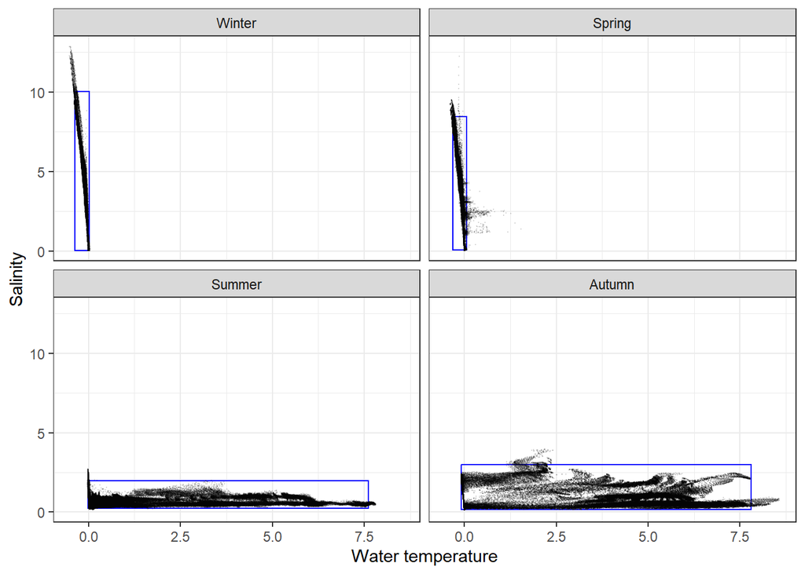

Для описания границ “экологической лицензии” биотопа (Ozerskii, 2011) который может быть потенциально заселен NIS, были вычислены пределы солености и температуры в акватории, прилегающей к районам портов, как значения 0.5% и 99.5% квантилей каждого из параметров. На рисунке эти границы обозначены прямоугольниками.

Таблица ++. Максимальные и минимальные значения солености, определяющие экологическую лицензию акватории

| Время года | Нижнее значение солености | Верхнее значение солености | Нижнее значение температуры воды | Верхнее значение температуры воды |
| --- | --- | --- | --- | --- |
| Winter | 0.02 | 10.04 | -0.37 | 0.02 |
| Spring | 0.07 | 8.44 | -0.32 | 0.07 |
| Summer | 0.23 | 1.99 | -0.01 | 7.62 |
| Autumn | 0.16 | 2.97 | -0.07 | 7.80 |

Значения температуры воды закономерно увеличиваются по мере удаления от устья Обской губы вверх по течению (Рис. ++).

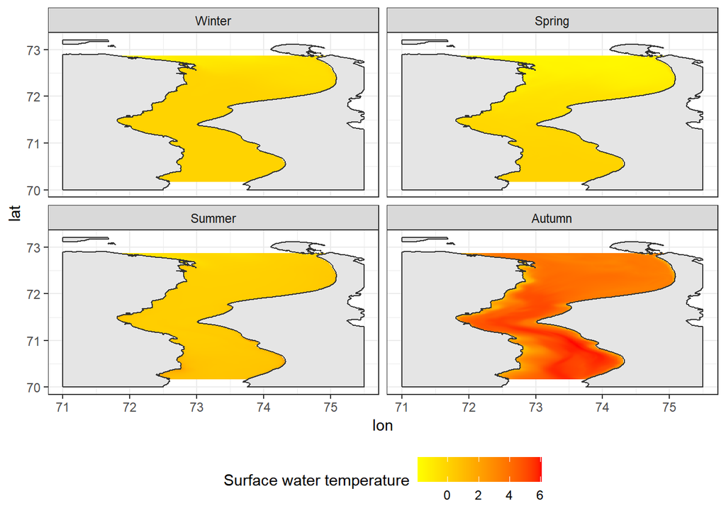

Соленость в акватории испытывает сезонные колебания (Рис. ++). Наиболее высокая соленость наблюдается весной, когда язык саленой воды заходит далеко вверх по течению.

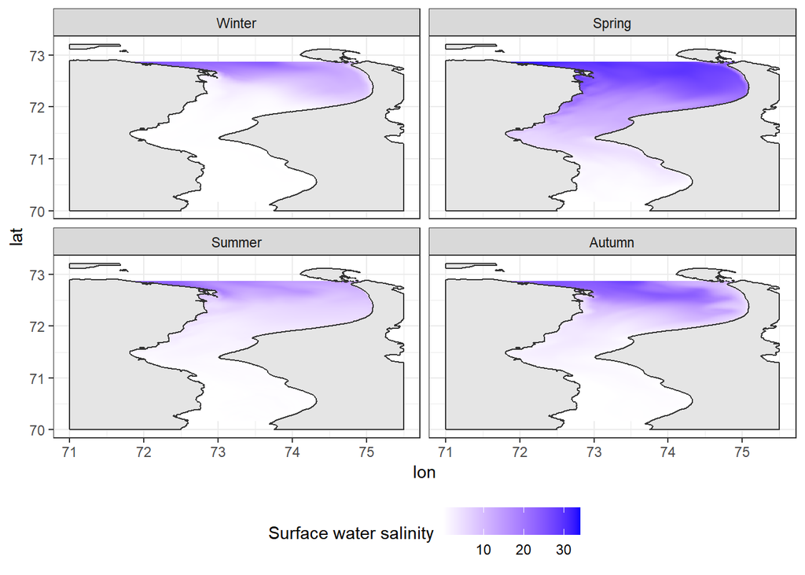

## Отбор потенциальных NIS

**(1)** Мы руководствовались изданием “Инвазионные виды России” (http://www.sevin.ru/top100worst/index.html ). По матералам этого издания мы выбрали те виды PNIS, которые описаны, как самые активные вселенцы в морских, солоноватоводных и пресных водоемов.

**(2)** Для расширения списка PNIS был сделан запрос из Глобальной базы данных инвазивных видов (Global invasive species database) Международного союза охраны природы (МСОП) http://www.iucngisd.org/gisd/. Из этой базы были извлечены названия пресноводных, солоноватоводных и морских бентосных и планктонных форм, которые были зарегистрированы, экспертами, модерирующими базу данных, как виды-вселенцы.

**(4)** В 2021, 2022 и 2023 гг. были проведены исследования ДНК, выделенной из балластных вод судов, курсирующих в Обской губе. Использование баркодинговых маркеров позволило идентифицировать несколько видов, чья ДНК присутствовала в балластных водах. В одном случае разрешающая способность метода не позволила однозначно найти соответствие полученных сиквенсов ни одному из видов рода *Cylichna* (Gastropoda, Opistobranchia). Поэтому в число PNIS мы включили два вида этого рода (*C.occulta* и *C.alba*), которые наиболее часто встречаются в северных морях.

## Селекция видов на основе парметров экологических ниш

Используя все источники информации был создан единый список видов, которые далее будут обозначаться как Potentialy Non Indigenous Species (**PNIS**). Всего в этот long list of potential NIS вошло 96 вида.

Таблица ++. Количество нативных и потенциально инвазивных видов среди разных экологических групп

| Экологическая группа | Нативные | PNIS | Обнаружена ДНК в балластных водах |
| --- | --- | --- | --- |
| Benthos | 41 | 81 | 4 |
| Phytoplancton | 64 | 3 | 2 |
| Plancton | 88 | 12 | 1 |

Для всех этих видов, как PNIS, так и нативных форм, используя базу [GBIF](https://www.gbif.org/) были получены координаты локаций, где эти виды были обнаружены всеми поставщиками данных этой базы. Всего была получена информация о 233913 уникальных локациях.

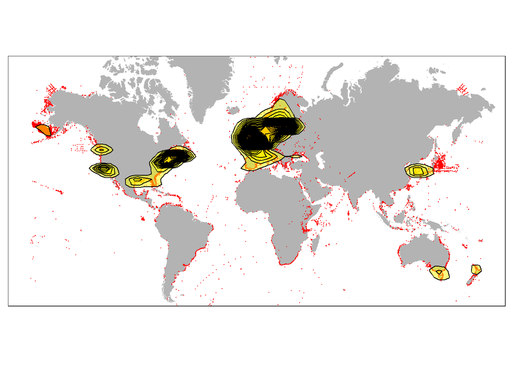

Рисунок ++. Локации потенциальных видов-вселенцев (PNIS), вошедших в расширенный список видов. Контурами обозначены участки макисмальной концентрации точек встреч.

Для всех видов, включенных в анализ (нативных и PNIS), производилась оценка значений солености и температуры в точках их встреч, взятых из базы GBIF. Для оценки гидрологических параметров в морских акваториях использовалась ГИС Bio-ORACLE (Tyberghein et al. 2021; Assis et al. 2017). Для каждой точки встреч из этой ГИС извлекали значения солености на средней глубине локации (mean at mean depth) и температуру воды на среденей глубине локации (mean at mean depth). Поскольку часть географических локаций видов приходилось на пресноводные акватории, дополнительно проводился поиск данных по температуре с использованием ГИС EarthEnv (Domisch et al., 2015). Для локаций, параметры которых оценивались по ГИС EarthEnv значение солености принималось равным нулю.

Среди PNIS отчетливо выделяется зона сгущения точек, попадающая в те же границы, на которые приходится концентрация точек нативных видов. Вместе с тем, лишь незначительное количество точек, соответствующих тем видам, ДНК которых была обнаружена в балластных водах попадают в этот диапазон.

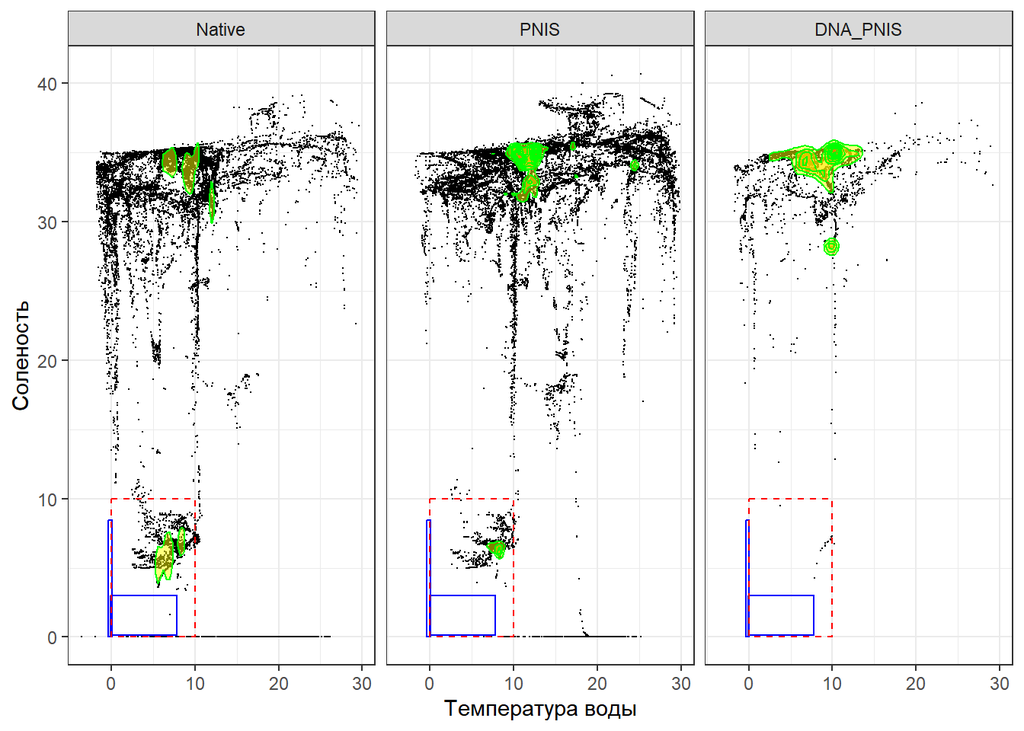

Рисунок ++. Характеристика экологических ниш нативных видов, отмеченных в Обской губе, потенциальных видов-вселенцев и видов, ДНК которых была отмечена в Балластных водах. Прямоугольники синего цвета отражают экологическую лицензию акватории Обской губы. Прямоугольник, очерченный красной пунктирной линией, отражает расширенную экологическую лицензию, выделенную с учетом потепления и возможного захода в акваторию соленых морских водных масс.

Для количественной оценки вероятности вселения PNIS в условия Обской губы мы ввели величину P_inv. Для вычисления этой величины мы оценили количество локаций, полученных из базы GBIF, для которых соленостно-температурные условия приблизительно соответствуют экологической лицензии акватории Обской губы (Соленость:0-10 промилле, Температура 0-10 градусов). Эта величина была отнесена к общему количеству локаций (отмеченных для данного вида в базе GBIF), для которых была проведена оценка солености и температуры. Значения этих показателей приведены в таблице ++.

Таблица ++. Оценка вероятности попадания потенциальных видов-вселенцев (PNIS) в эстуарий Обской губы. N_occ_in_env - количество ссылок в базе данных GBIF с параметрами окружающей среды, близкими к экологической лицензии акватории. N_occ_total - общее количество ссылок в базе данных GBIF

| species | Status | Group | N_occ_in_env | N_occ_total | P_inv |
| --- | --- | --- | --- | --- | --- |
| Carcinus maenas | PNIS | Benthos | 10 | 19385 | 0.0005 |
| Littorina littorea | PNIS | Benthos | 7 | 13461 | 0.0005 |
| Potamopyrgus antipodarum | PNIS | Benthos | 2668 | 7796 | 0.3422 |
| Amphibalanus improvisus | PNIS | Benthos | 6638 | 7698 | 0.8623 |
| Crassostrea gigas | PNIS | Benthos | 2 | 7385 | 0.0003 |
| Mya arenaria | PNIS | Benthos | 1043 | 3307 | 0.3154 |
| Cylichna alba | DNA_PNIS | Benthos | 1 | 2993 | 0.0003 |
| Gammarus tigrinus | PNIS | Benthos | 1218 | 2687 | 0.4533 |
| Rangia cuneata | PNIS | Benthos | 61 | 2484 | 0.0246 |
| Paracalanus parvus | PNIS | Plancton | 4 | 1388 | 0.0029 |
| Alitta succinea | PNIS | Benthos | 1 | 1318 | 0.0008 |
| Dreissena polymorpha | PNIS | Benthos | 538 | 1257 | 0.4280 |
| Gymnodinium catenatum | PNIS | Phytoplancton | 3 | 878 | 0.0034 |
| Mnemiopsis leidyi | PNIS | Plancton | 7 | 708 | 0.0099 |
| Eriocheir sinensis | PNIS | Benthos | 119 | 611 | 0.1948 |
| Rhithropanopeus harrisii | PNIS | Benthos | 216 | 506 | 0.4269 |
| Platorchestia platensis | PNIS | Benthos | 1 | 505 | 0.0020 |
| Alexandrium minutum | PNIS | Phytoplancton | 3 | 491 | 0.0061 |
| Acartia bifilosa | PNIS | Plancton | 279 | 473 | 0.5899 |
| Physella acuta | PNIS | Benthos | 1 | 464 | 0.0022 |
| Acartia tonsa | PNIS | Plancton | 8 | 438 | 0.0183 |
| Pacifastacus leniusculus | PNIS | Benthos | 58 | 391 | 0.1483 |
| Musculista senhousia | PNIS | Benthos | 1 | 380 | 0.0026 |
| Pseudosuccinea columella | PNIS | Benthos | 1 | 173 | 0.0058 |
| Mytilopsis leucophaeata | PNIS | Benthos | 4 | 163 | 0.0245 |
| Bythotrephes longimanus | PNIS | Plancton | 1 | 160 | 0.0063 |
| Dreissena rostriformis | PNIS | Benthos | 1 | 144 | 0.0069 |
| Planorbella duryi | PNIS | Benthos | 2 | 129 | 0.0155 |
| Acanthocyclops robustus | PNIS | Plancton | 8 | 119 | 0.0672 |
| Corbicula fluminalis | PNIS | Benthos | 1 | 83 | 0.0120 |
| Lithoglyphus naticoides | PNIS | Benthos | 2 | 66 | 0.0303 |
| Potamothrix heuscheri | PNIS | Benthos | 16 | 50 | 0.3200 |
| Dikerogammarus haemobaphes | PNIS | Benthos | 2 | 42 | 0.0476 |
| Pedospumella | DNA_PNIS | Phytoplancton | 1 | 42 | 0.0238 |
| Potamothrix vejdovskyi | PNIS | Benthos | 5 | 37 | 0.1351 |
| Procambarus virginalis | PNIS | Benthos | 1 | 34 | 0.0294 |
| Eurytemora velox | PNIS | Plancton | 5 | 27 | 0.1852 |
| Thraustochytrium aureum | DNA_PNIS | Phytoplancton | 14 | 24 | 0.5833 |
| Gmelinoides fasciatus | PNIS | Benthos | 2 | 19 | 0.1053 |
| Didymosphenia geminatum | PNIS | Phytoplancton | 1 | 17 | 0.0588 |
| Cercopagis pengoi | PNIS | Plancton | 11 | 16 | 0.6875 |
| Pontogammarus robustoides | PNIS | Benthos | 6 | 15 | 0.4000 |
| Euilyodrilus heuscheri | PNIS | Benthos | 7 | 10 | 0.7000 |
| Euilyodrilus vejdovskyi | PNIS | Benthos | 4 | 9 | 0.4444 |
| Ilyodrilus heuscheri | PNIS | Benthos | 1 | 8 | 0.1250 |
| Orconectes virilis | PNIS | Benthos | 1 | 5 | 0.2000 |
| Paramysis lacustris | PNIS | Benthos | 2 | 3 | 0.6667 |
| Paramysis intermedia | PNIS | Benthos | 1 | 2 | 0.5000 |

Для создания сокращенного списка видов мы включили в дальнейший анализ только те PNIS, для которых в базе GBIF было найдено более 10 записей точек встречи. Для видов с меньшим количеством встреч оценки вероятности попадания в диапазон экологической лицензии Обской губы будут недостоверны из-за высокой статистической ошибки, вызванной малым объемом данных. Среди оставшихся 42 видов мы отобрали те формы, у которых величина P_inv была выше 0.05 (5%). Всего было выделено 18 видов, удовлетворяющих этим условиям. Большинство из этих видов - это бентосные форм (Таблица ++). Также в число потенциальных вселенцев попадают 4 вида планктонных животных и 2 вида фитопланктонна, среди которых 1 обнаружен в балластных водах при изучении выделенной оттуда ДНК.

Таблица ++. Количество видов PNIS среди разных экологических групп организмов

[output not shown]

Важно отметить, что *Eurytemora velox*, вспышку которой отметили в 2022-2023 попадает в шорт-лист PNIS. Величина, характеризующая вероятность попадания в экологическую лицензию Обской губы для данного вида составляет P_inv = 0.1852. Таким образом, вид, чье недавнее вселение в акваторию может быть весьма вероятным, вполне соответствует критериям отбора PNIS, примененным в данной работе.

## Описание наиболее вероятных инвайдеров

### Зоопланктон

##### *Acanthocyclops robustus Mastrantuono & Stella, 1976*

**Phyllum:**Arthropoda  
**Class:** Copepoda  
**Order:** Cyclopoida  
**Family:** Cyclopidae

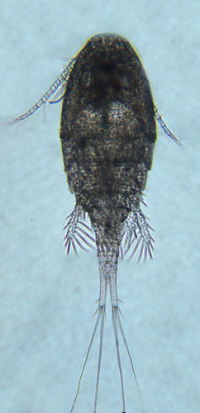

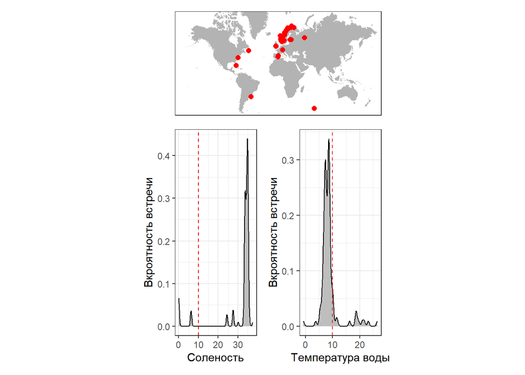

Figure ++. Worldwide distribution of Acanthocyclops robustus accordingly to GBIF.

##### *Acartia bifilosa Steuer, 1910*

**Phyllum:**Arthropoda  
**Class:** Copepoda  
**Order:** Calanoida  
**Family:** Acartiidae

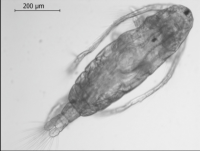

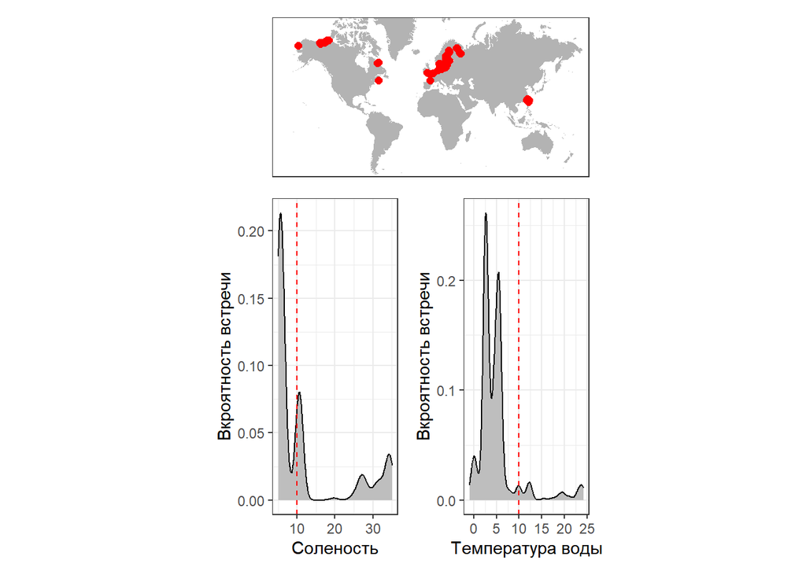

Figure ++. Worldwide distribution of Acartia bifilosa accordingly to GBIF.

*A. bifilosa* is eryhaline species inhabiting estuaries in the Western Europe (Belgiun, Netherlands), is constituent of brakish-water-marine group in winter-spring (Sautour, Castel, 1995)[^3]. May survive salinities down to 6-12 psu and temperatures down to 0°C. Was found in estuaries of the northern Europe. *A. bifilosa* is normal component of the summer planktonic community in the White Sea, prefers waters with low salinities in estuaries (Prudkovsky, 2003)[^4]. *A. bifilosa* lays resting eggs to survive unfavourable conditions. The latter fact may facilitate transfer of this species in ballast waters. *A. bifilosa* is basically herbivorous species, which is capable to feed on animal preys, when phytoplankton is scarce (Martynova et al., 2011)[^5]. This may lead to competitive pressure of this species on local herbivorous organisms, and negative changes in populations of the latter.

##### *Cercopagis pengoi*

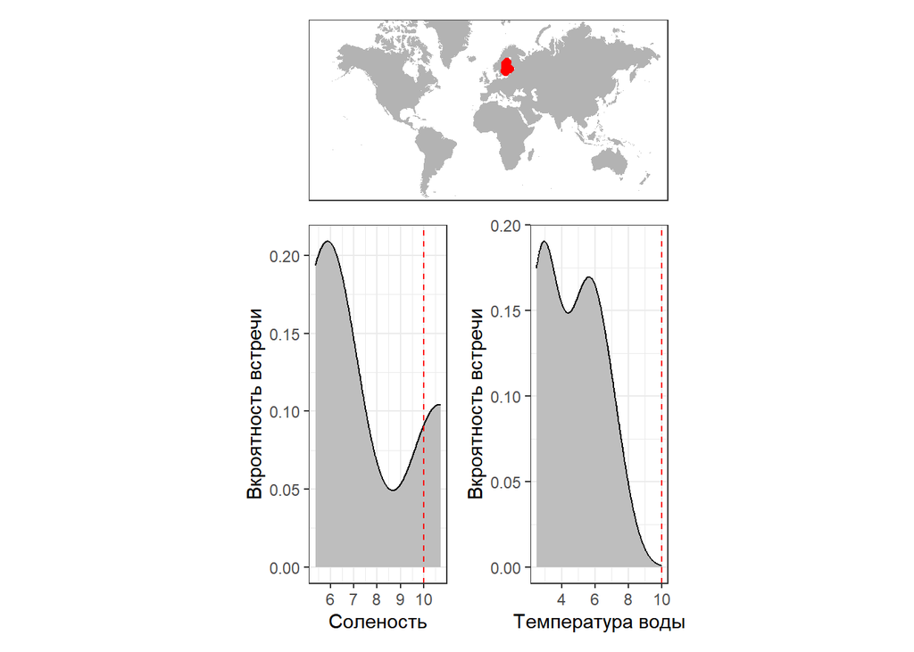

Figure ++. Worldwide distribution of Cercopagis pengoi accordingly to GBIF.

##### *Eurytemora velox (Lilljeborg, 1853)*

**Phyllum:**Arthropoda  
**Class:** Copepoda  
**Order:** Calanoida  
**Family:** Temoridae

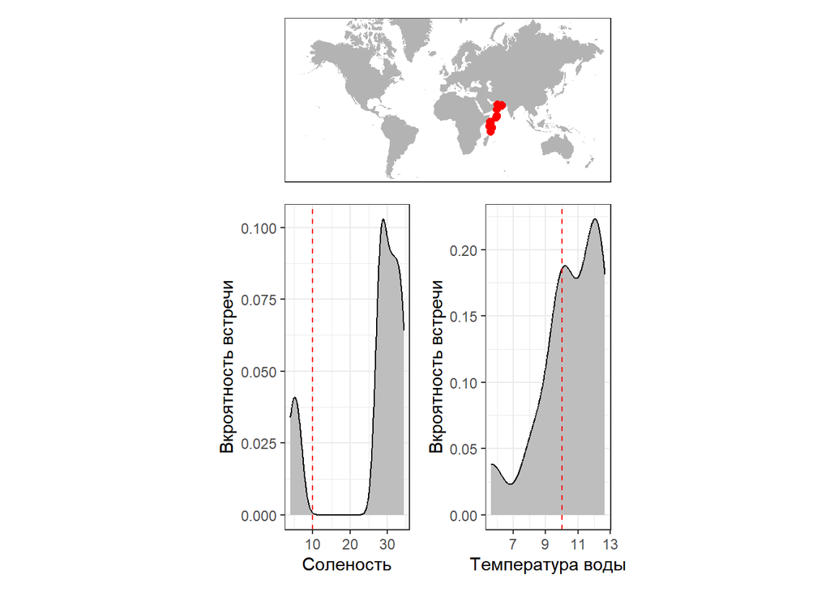

Figure ++. Worldwide distribution of Eurytemora velox accordingly to GBIF.

### Benthos

##### *Amphibalanus improvisus (Darwin, 1854)*

**Phyllum:**Arthropoda  
**Class:** Thecostraca  
**Order:** Balanomorpha  
**Family:** Balanidae

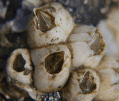

http://www.sevin.ru/top100worst/priortargets/Arthropods/improvisus.gif

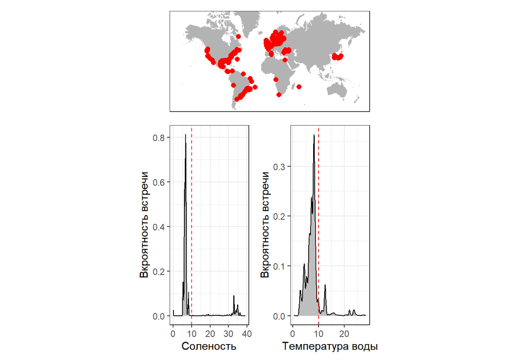

Figure ++. Worldwide distribution of Amphibalanus improvisus accordingly to GBIF.

These sessile crustaceans have planktonic larvae, so the most likely way of their invasion into the Ob estuary is the introduction with ballast water. The second route of entry is also possible: on the bottoms of ships. Adult barnacles attached to the hulls of boats would not be able to inhabit the area. However, after cross copulation (they are hermaphroditic animals) the fertilized eggs accumulate in a special cavity where eggs develop and nauplius larvae hatched (Dorit et al. 1991)[^6]. Then the already formed larvae enter the water column and, after a certain period of swimming, settle on solid substrates and undergo metamorphosis. If vessels with adults of this species regularly enter the Ob estuary, a successful emergence of the nauplii may take place if the temperature is high enough and the salinity is at least 2 ppm (Dineen, Hines, 1992)[^7].

In the case of successful colonization, barnacles inhabiting hard substrates (including man-made ones) will increase the structure complexity of the bottom. In the space between the calcareous barnacle’s shells other benthic forms will be able to settle. In case of mass settlement, which is unlikely, there may be failures in underwater structures: increase in friction, decrease in pipelines capacity.

##### *Gammarus tigrinus Sexton, 1939*

**Phyllum:**Arthropoda  
**Class:** Malacostraca  
**Order:** Amphipoda  
**Family:** Gammaridae

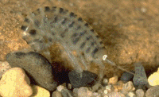

http://www.sevin.ru/top100worst/priortargets/Arthropods/tigrinus.gif

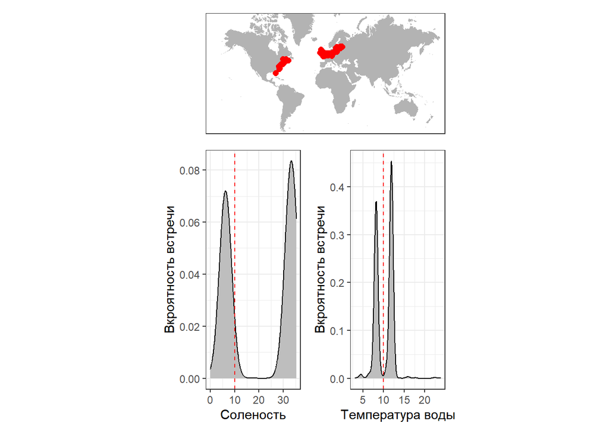

Figure ++. Worldwide distribution of Gammarus tigrinus accordingly to GBIF.

The most likely vector of introduction of this species is ballast water (Berezina, 2007)[^8]. The critical factor limiting the normal development of this euryhaline amphipod is temperature. This species can enter reproduction as early as 2 degrees, but developmental duration is delayed at low temperatures (Chambers, 1976)[^9].

If introduced successfully, this species could significantly alter the ecosystem structure of the Ob Estuary. The expected impact may be due to the fact that this species is polyphagous and can feed not only on detritus, but also on animals including oligochaetes (Most dangerous invasive species …, 2018)[^10], which dominate the benthic communities in the south part of the estuary. The second expected impact may be related to the competitive relationship of the invasive species with native amphipods, primarily Monoporeia affinis. The latter species, being one of the most abundant forms of benthos (Integrated investigations… 2020)[^11], serve as the basis of diet of valuable fish species inhabiting the Ob estuary(Stepanova 2017)[^12].

It should be noted that an in-depth taxonomic survey of the gammarid fauna in the Ob estuary has not been conducted. Therefore, there is a possibility that this species is already represented in the water area.

##### *Rhithropanopeus harrisii (Gould, 1841)*

**Phyllum:**Arthropoda  
**Class:** Malacostraca  
**Order:** Decapoda  
**Family:** Panopeidae

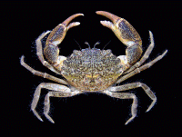

http://www.sevin.ru/top100worst/priortargets/Arthropods/harrisii.gif

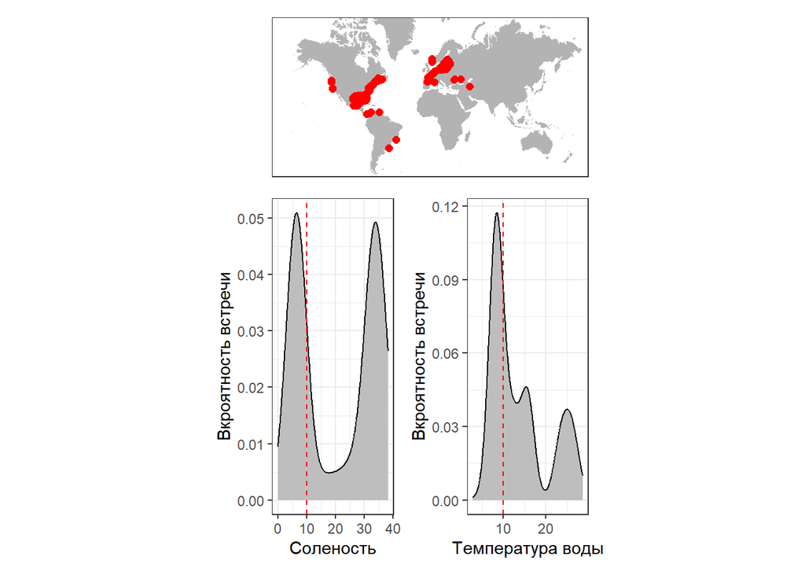

Figure ++. Worldwide distribution of Rhithropanopeus harrisii accordingly to GBIF.

The main expected vector of transport is ballast water. However, since the crab is very small in size, its infestation is also possible due to ship bottom fouling (Most dangerous invasive species…, 2018 )[^13]. The presence of this species in *Dreissena polymorpha* druses seems most likely.

The crab is omnivorous (Most dangerous invasive species …, 2018)[^14], which determines its potential threat to native benthos species.

##### *Eriocheir sinensis H. Milne Edwards, 1853*

**Phyllum:**Arthropoda  
**Class:** Malacostraca  
**Order:** Decapoda  
**Family:** Varunidae

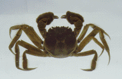

http://www.sevin.ru/top100worst/priortargets/Arthropods/sinensis.gif

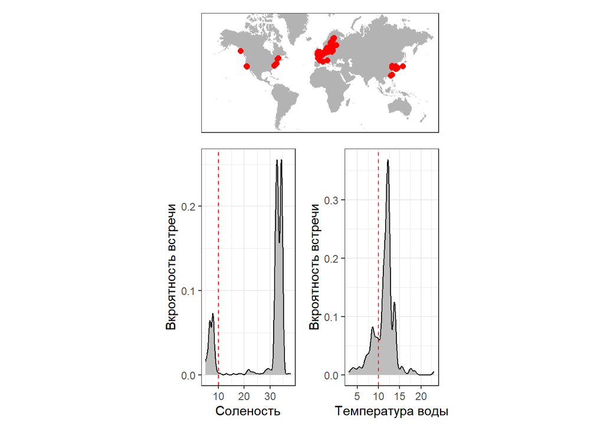

Figure ++. Worldwide distribution of Eriocheir sinensis accordingly to GBIF.

It is one of the most successful invasive species moving northward (Most dangerous invasive species…, 2018)[^15]. At present, this species was undoubtly occured in the estuaries of the White Sea (Berger and Naumov, 2002)[^16].

The species belongs to cathodromic organisms, i.e. it migrates from the sea to fresh waters and backward (Most dangerous invasive species…, 2018)[^17]. Therefore, potentially, with time, it can reach the Ob estuary by natural way. It is also possible to disperse with ballast water (due to pelagic larvae) and as part of ship bottom fouling (The most dangerous invasive species…, 2018)[^18].

The species is very tolerant to low temperature (The most dangerous invasive species …, 2018)[^19] thus its occurrence in the Ob estuary is very probable.

When introduced, this species, being a polyphagous, can significantly impact on both benthic invertebrates and on fish, eating their eggs (Most dangerous invasive species …, 2018)[^20]. Another potential impact could be digging of burrowes that can reach several tens of centimeters (Most Dangerous Invasive Species …, 2018)[^21], this can destabilize bottom sediment .

##### *Dreissena polymorpha Seninski, 1905*

**Phyllum:**Mollusca  
**Class:** Bivalvia  
**Order:** Myida  
**Family:** Dreissenidae

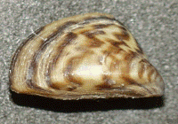

http://www.sevin.ru/top100worst/priortargets/Mollusca/polymorpha.gif

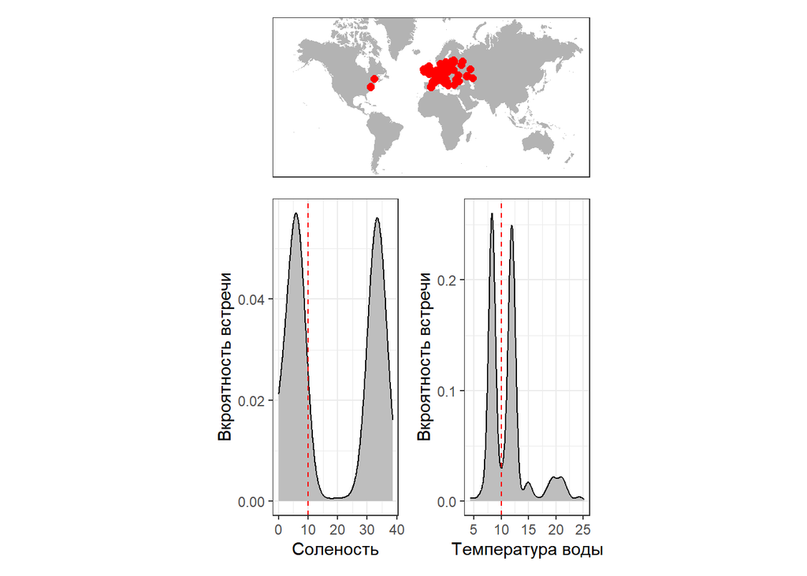

Figure ++. Worldwide distribution of Dreissena polymorpha accordingly to GBIF.

In the case of successful colonization, clams will be able to form settlements on natural hard substrates and hydro-technical constructions. The most likely places of settlement formation are pipelines associated with heated water. This can lead to reduced efficiency or equipment failure.

The impact of these mollusks on the ecosystem is ambiguous (Karatayev, 2007)[^24]. On the one hand, by increasing the structure complexity of the biotope, additional microbiotopes for native species (oligochaetes, crustaceans) may appear. On the other hand, filter mollusks may lead to a decrease in the abundance of phytoplankton. It is important that settlements of this species may lead to changes in the content of biogens in water (Karatayev, 2007)[^25], which may significantly increase the phytobenthos development.

If the invasion of this species occurs, it seems apectedly to spread upstream of the Ob River, where, most likely, dense settlements will be formed.

##### *Mya arenaria Linnaeus, 1758*

**Phyllum:**Mollusca  
**Class:** Bivalvia  
**Order:** Myida  
**Family:** Myidae  
`

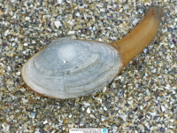

https://www.meerwasser-lexikon.de/imgHaupt/52049_58ddf591ae3e0.jpg

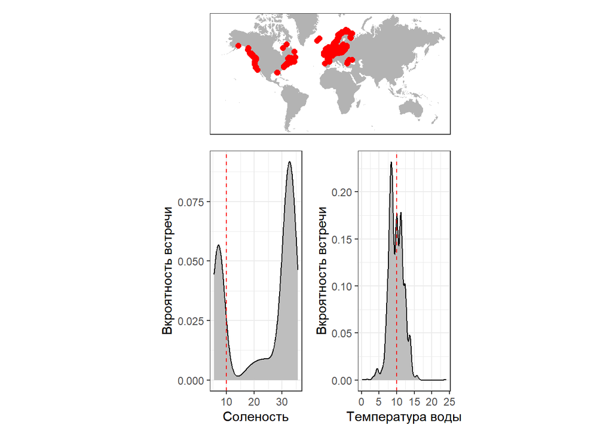

Figure ++. Worldwide distribution of Mya arenaria accordingly to GBIF.

Despite the fact that this species successfully colonizes the cold estuaries of Alaska (Powers et al., 2006)[^26], it is more likely to belong to the marine fauna. So its invasion, if it occurs, will expectedly be associated with deep-water areas where more dense sea water enters.

This burrowing in muddy sediments bivalve feeds on suspended benthic organic particles. In the White Sea, where temperature conditions are close to the Arctic seas, this species may show high abundance (Gerasimova et al., 2021)[^27]. In the Black Sea, where this species has recently introduced, the formation of dense aggregations of this species has led to some changes in sedimentation patterns (Zolotarev, 1996)[^28]. Through burrowing activity, these molluscs may contribute to sediment aeration and slow the formation of hydrogen sulfide in bottom sediments (Hansen et al., 1996)[^29], positively affecting the infauna. Therefore, there is no reason to predict a significant negative impact of this species on the Ob estuary ecosystem.

##### *Potamopyrgus antipodarum (J. E. Gray, 1843)*

**Phyllum:**Mollusca  
**Class:** Gastropoda  
**Order:** Littorinimorpha  
**Family:** Tateidae

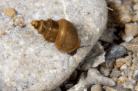

http://www.sevin.ru/top100worst/priortargets/Mollusca/antipodarum.gif

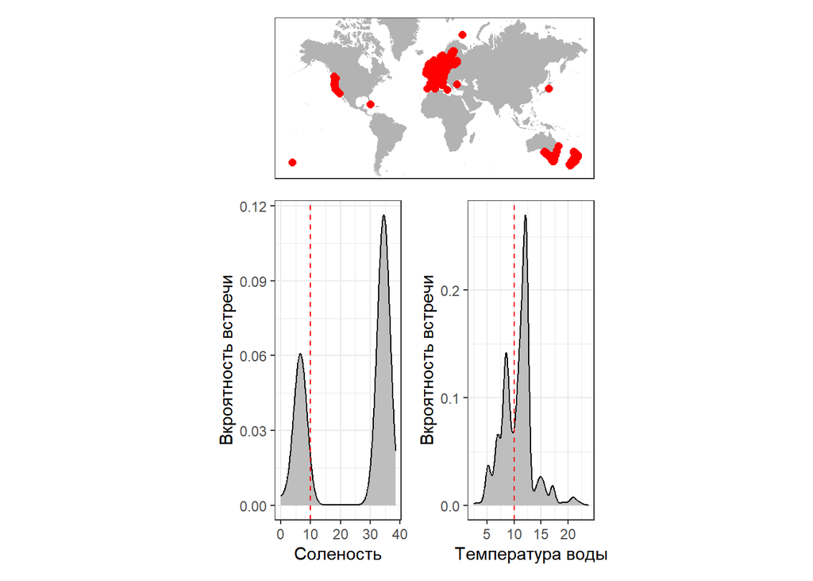

Figure ++. Worldwide distribution of Potamopyrgus antipodarum accordingly to GBIF.

The most probable way of introdction of this species is with billast water. However, due to the fact that this species well tolerates passage through the digestive tract of birds (The most dangerous invasive species…, 2018)[^30], natural introduction of this species is also possible. However, in the development of this scenario, the spread of the species will take place, rather, from the upper Ob-Yenisei system. In the case of formation of *Dreissena polymorpha* populations in the Ob estuary, it will be able to actively colonize this biotope (The most dangerous invasive species…, 2018)[^31]. There is no reliable basis for predicting the consequences (both negative and positive) of the invasion of this species.

##### *Pacifastacus leniusculus (Dana, 1852)*

**Phyllum:**Arthropoda  
**Class:** Malacostraca  
**Order:** Decapoda  
**Family:** Astacidae

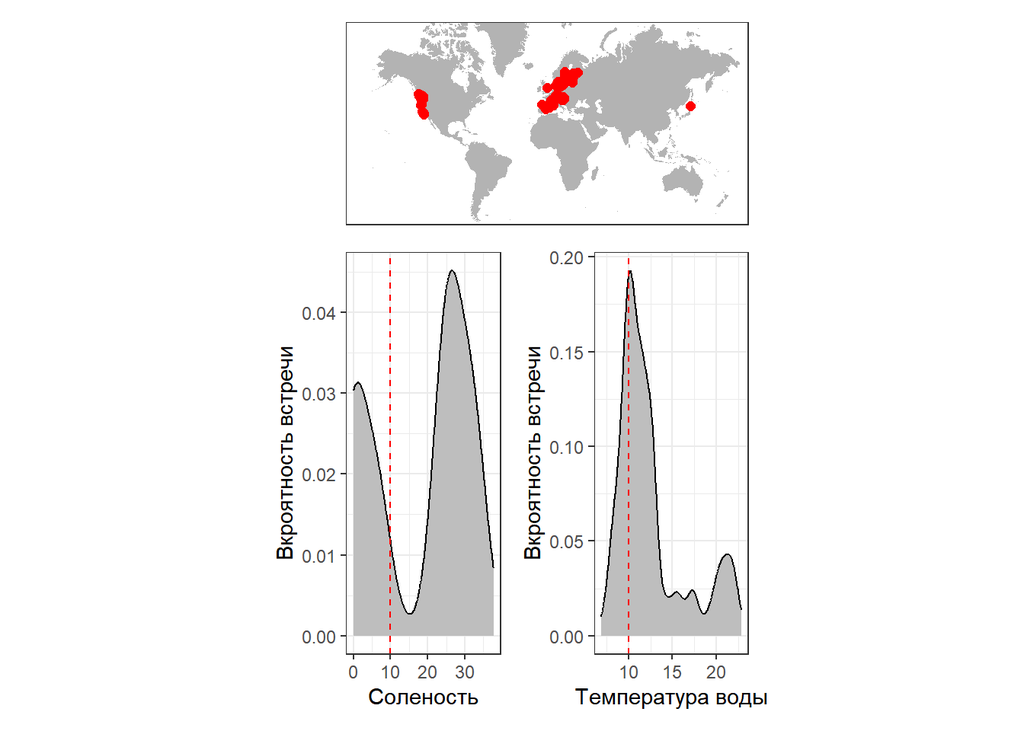

Figure ++. Worldwide distribution of Pacifastacus leniusculus accordingly to GBIF.

##### *Potamothrix heuscheri (Bretscher, 1900)*

**Phyllum:**Annelida  
**Class:** Clitellata  
**Order:** Tubificida  
**Family:** Naididae

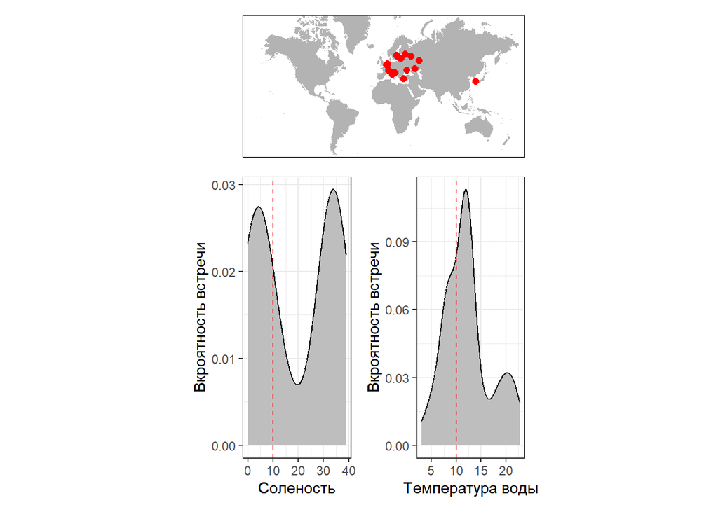

Figure ++. Worldwide distribution of Potamothrix heuscheri accordingly to GBIF.

##### *Potamothrix vejdovskyi (Hrabĕ, 1941)*

**Phyllum:**Annelida  
**Class:** Clitellata  
**Order:** Tubificida  
**Family:** Naididae

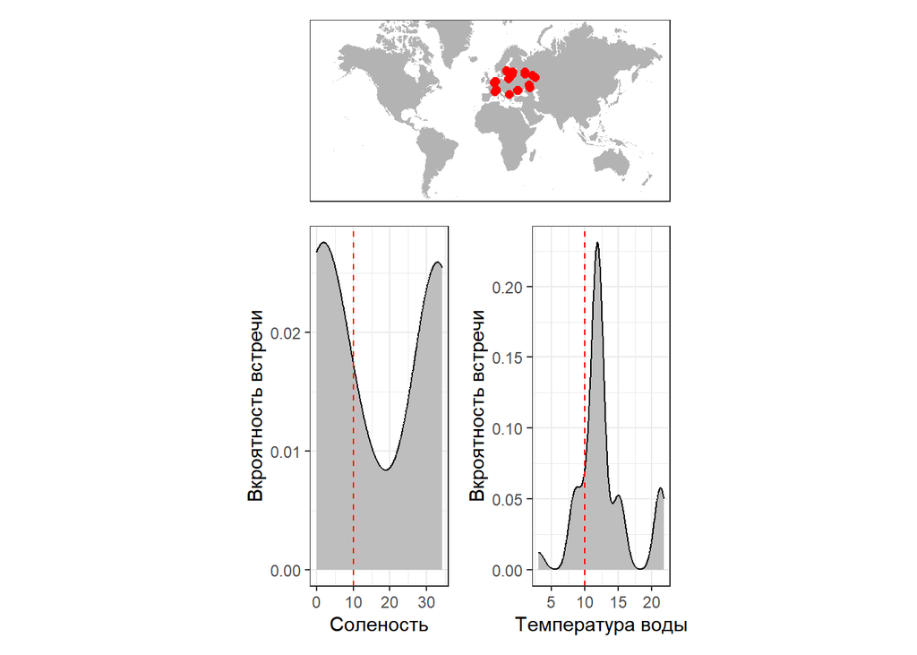

Figure ++. Worldwide distribution of Potamothrix vejdovskyi accordingly to GBIF.

##### *Gmelinoides fasciatus (Stebbing, 1899)*

**Phyllum:**Arthropoda  
**Class:** Malacostraca  
**Order:** Amphipoda  
**Family:** Micruropodidae

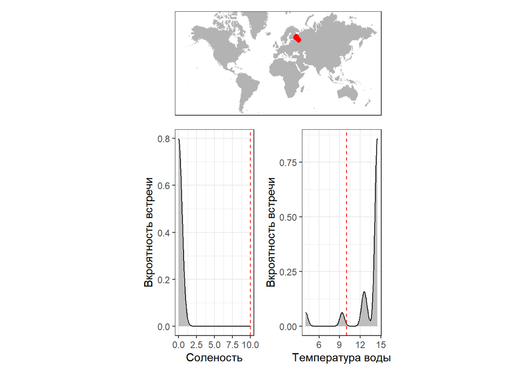

Figure ++. Worldwide distribution of Gmelinoides fasciatus accordingly to GBIF.

##### *Pontogammarus robustoides (Sars, 1894)*

**Phyllum:**Arthropoda  
**Class:** Malacostraca  
**Order:** Amphipoda  
**Family:** Pontogammaridae

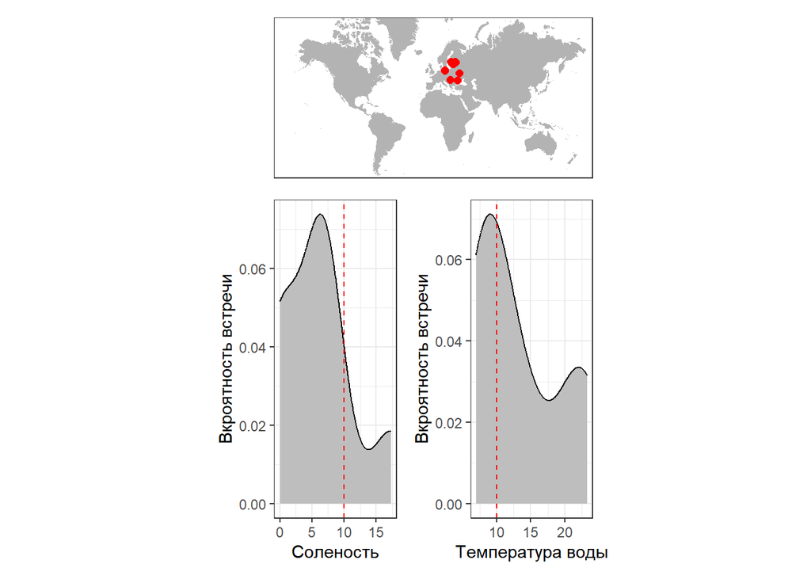

Figure ++. Worldwide distribution of Pontogammarus robustoides accordingly to GBIF.

### Фитопланктон

##### *Didymosphenia geminatum M.Schmidt, 1899*

**Phyllum:**Heterokontophyta  
**Class:** Bacillariophyceae  
**Order:** Cymbellales  
**Family:** Cymbellaceae

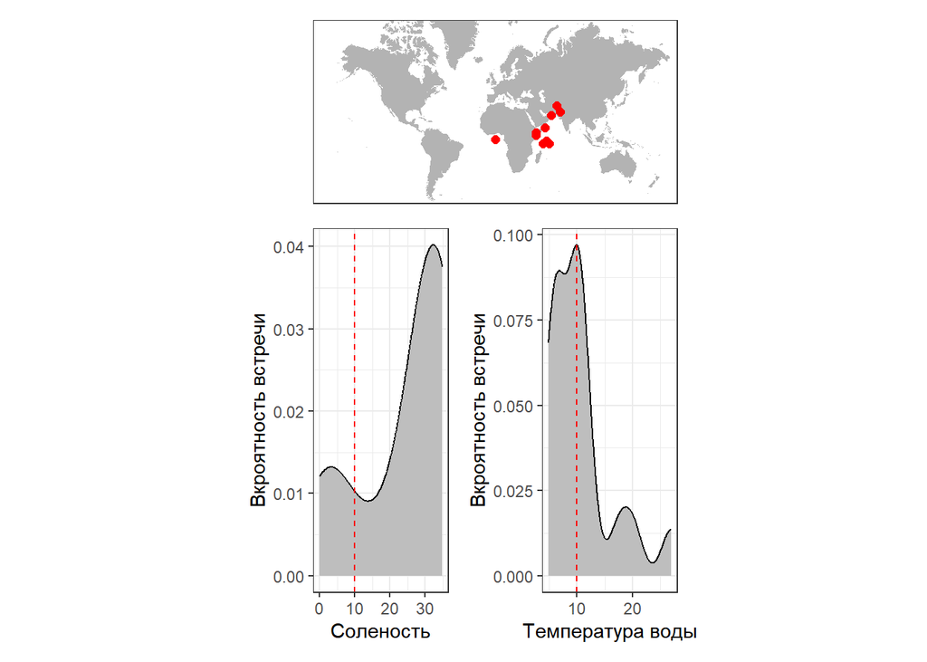

Figure ++. Worldwide distribution of Didymosphenia geminatum accordingly to GBIF.

##### *Thraustochytrium aureum Goldstein, 1963*

**Phyllum:**Bigyra  
**Class:** Labyrinthulea  
**Order:** Thraustochytrida  
**Family:** Thraustochytriaceae

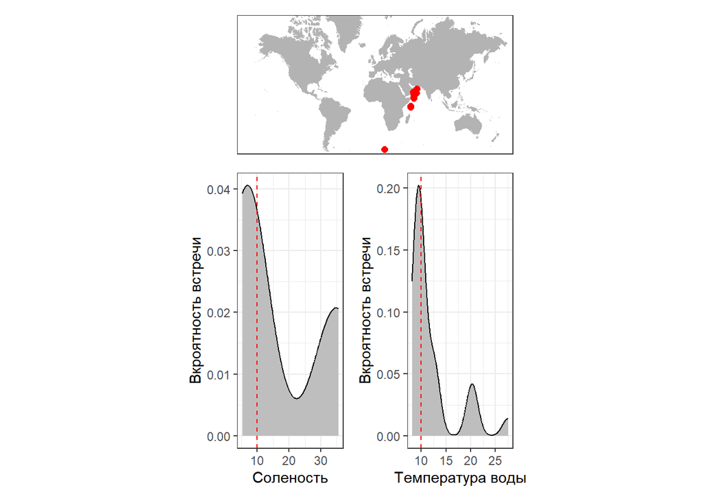

Figure ++. Worldwide distribution of Thraustochytrium aureum accordingly to GBIF.